# Assignment 3

```r
# Library required
library(ggplot2)
library(data.table)
library(dplyr)
library(DT)
library(tidyverse)
library(moments)
```

# Reading data

Please use data set COVID19.csv for next questions. This data set is in a raw format. You have to clean this dataset before any analysis. Data set is totally raw downloaded from worldmeters today (March 1st 2021) (https://www.worldometers.info/coronavirus/). Hence, data cleaning and manipulation are required. Please also explain your results with numerical summary as well as graphs, wherever it is applicable. Please check your data also, if it is skewed or normally distributed. Results should be based on skewness or normal distribution.

```r
# Reading data set
COVID19_raw <- read.csv("COVID19.csv",
                        stringsAsFactors = FALSE,
                     na.strings=c("","NA"))
str(COVID19_raw)
```

```
## 'data.frame':    237 obs. of  20 variables:
##  $ X                  : int  1 2 3 4 5 6 7 8 9 10 ...
##  $ X.                 : int  NA NA NA NA NA NA NA NA 1 2 ...
##  $ Country.Other      : chr  "North America" "Asia" "South America" "Europe" ...
##  $ TotalCases         : chr  "3,35,65,070" "2,50,06,779" "1,79,91,688" "3,41,49,236" ...
##  $ NewCases           : chr  "3,360" "2,278" "463" "2,097" ...
##  $ TotalDeaths        : chr  "7,59,891" "3,98,356" "4,66,860" "8,13,232" ...
##  $ NewDeaths          : int  468 36 21 25 NA NA NA 550 NA NA ...
##  $ TotalRecovered     : chr  "2,32,48,152" "2,35,18,954" "1,62,59,018" "2,36,98,937" ...
##  $ NewRecovered       : chr  "3,964" "3,406" "479" "165" ...
##  $ ActiveCases        : chr  "95,57,027" "10,89,469" "12,65,810" "96,37,067" ...
##  $ Serious.Critical   : chr  "21,321" "21,930" "18,955" "25,544" ...
##  $ Tot.Cases.1M.pop   : chr  NA NA NA NA ...
##  $ Deaths.1M.pop      : chr  NA NA NA NA ...
##  $ TotalTests         : chr  NA NA NA NA ...
##  $ Tests.1M.pop       : chr  NA NA NA NA ...
##  $ Population         : chr  NA NA NA NA ...
##  $ Continent          : chr  "North America" "Asia" "South America" "Europe" ...
##  $ X1.Caseevery.X.ppl : chr  NA NA NA NA ...
##  $ X1.Deathevery.X.ppl: chr  NA NA NA NA ...
##  $ X1.Testevery.X.ppl : chr  NA NA NA NA ...
```

```r
datatable(COVID19_raw)
```

|  | X | X. | Country.Other | TotalCases | NewCases | TotalDeaths | NewDeaths | TotalRecovered | NewRecovered | ActiveCases | Serious.Critical | Tot.Cases.1M.pop | Deaths.1M.pop | TotalTests | Tests.1M.pop | Population | Continent | X1.Caseevery.X.ppl | X1.Deathevery.X.ppl | X1.Testevery.X.ppl |
| --- | --- | --- | --- | --- | --- | --- | --- | --- | --- | --- | --- | --- | --- | --- | --- | --- | --- | --- | --- | --- |
| 1 | 1 |  | North America | 3,35,65,070 | 3,360 | 7,59,891 | 468 | 2,32,48,152 | 3,964 | 95,57,027 | 21,321 |  |  |  |  |  | North America |  |  |  |
| 2 | 2 |  | Asia | 2,50,06,779 | 2,278 | 3,98,356 | 36 | 2,35,18,954 | 3,406 | 10,89,469 | 21,930 |  |  |  |  |  | Asia |  |  |  |
| 3 | 3 |  | South America | 1,79,91,688 | 463 | 4,66,860 | 21 | 1,62,59,018 | 479 | 12,65,810 | 18,955 |  |  |  |  |  | South America |  |  |  |
| 4 | 4 |  | Europe | 3,41,49,236 | 2,097 | 8,13,232 | 25 | 2,36,98,937 | 165 | 96,37,067 | 25,544 |  |  |  |  |  | Europe |  |  |  |
| 5 | 5 |  | Africa | 39,24,598 |  | 1,03,868 |  | 34,84,084 |  | 3,36,646 | 2,555 |  |  |  |  |  | Africa |  |  |  |
| 6 | 6 |  | Oceania | 51,168 | 7 | 1,088 |  | 34,286 | 7 | 15,794 | 6 |  |  |  |  |  | Australia/Oceania |  |  |  |
| 7 | 7 |  |  | 721 |  | 15 |  | 706 |  | 0 | 0 |  |  |  |  |  |  |  |  |  |
| 8 | 8 |  | World | 11,46,89,260 | 8,205 | 25,43,310 | 550 | 9,02,44,137 | 8,021 | 2,19,01,813 | 90,311 | 14,714 | 326.3 |  |  |  | All |  |  |  |
| 9 | 9 | 1 | USA | 2,92,55,344 |  | 5,25,776 |  | 1,96,94,306 |  | 90,35,262 | 14,786 | 88,042 | 1,582 | 35,90,21,570 | 10,80,451 | 33,22,88,557 | North America | 11 | 632 | 1 |
| 10 | 10 | 2 | India | 1,11,12,241 | 185 | 1,57,195 |  | 1,07,86,457 | 1,889 | 1,68,589 | 8,944 | 8,000 | 113 | 21,68,58,774 | 1,56,129 | 1,38,89,75,299 | Asia | 125 | 8,836 | 6 |

[output cut: 227 more lines]

# Data cleaning

## Question 1. Just keep rows containing country information. Remove rest of the rows. Apart from country, you should not be having any other row. Next step will only be done after finishing this question.

- Removing unnecessary rows

```r
COVID19_row_cleaning <- COVID19_raw %>%
  slice(9:229) %>% # function to inculde specific rows
  select(3:20)

datatable(COVID19_row_cleaning)
```

|  | Country.Other | TotalCases | NewCases | TotalDeaths | NewDeaths | TotalRecovered | NewRecovered | ActiveCases | Serious.Critical | Tot.Cases.1M.pop | Deaths.1M.pop | TotalTests | Tests.1M.pop | Population | Continent | X1.Caseevery.X.ppl | X1.Deathevery.X.ppl | X1.Testevery.X.ppl |
| --- | --- | --- | --- | --- | --- | --- | --- | --- | --- | --- | --- | --- | --- | --- | --- | --- | --- | --- |
| 1 | USA | 2,92,55,344 |  | 5,25,776 |  | 1,96,94,306 |  | 90,35,262 | 14,786 | 88,042 | 1,582 | 35,90,21,570 | 10,80,451 | 33,22,88,557 | North America | 11 | 632 | 1 |
| 2 | India | 1,11,12,241 | 185 | 1,57,195 |  | 1,07,86,457 | 1,889 | 1,68,589 | 8,944 | 8,000 | 113 | 21,68,58,774 | 1,56,129 | 1,38,89,75,299 | Asia | 125 | 8,836 | 6 |
| 3 | Brazil | 1,05,51,259 |  | 2,55,018 |  | 94,11,033 |  | 8,85,208 | 8,318 | 49,407 | 1,194 | 2,86,00,000 | 1,33,920 | 21,35,59,824 | South America | 20 | 837 | 7 |
| 4 | Russia | 42,46,079 |  | 86,122 |  | 38,11,797 |  | 3,48,160 | 2,300 | 29,088 | 590 | 11,10,00,000 | 7,60,399 | 14,59,76,024 | Europe | 34 | 1,695 | 1 |
| 5 | UK | 41,76,554 |  | 1,22,849 |  | 29,05,317 |  | 11,48,388 | 1,971 | 61,310 | 1,803 | 8,91,62,545 | 13,08,859 | 6,81,22,332 | Europe | 16 | 555 | 1 |
| 6 | France | 37,55,968 |  | 86,454 |  | 2,54,868 |  | 34,14,646 | 3,430 | 57,458 | 1,323 | 5,18,53,607 | 7,93,240 | 6,53,69,365 | Europe | 17 | 756 | 1 |
| 7 | Spain | 31,88,553 |  | 69,142 |  | 26,47,446 |  | 4,71,965 | 3,021 | 68,180 | 1,478 | 3,84,91,517 | 8,23,052 | 4,67,66,806 | Europe | 15 | 676 | 1 |
| 8 | Italy | 29,25,265 |  | 97,699 |  | 24,05,199 |  | 4,22,367 | 2,231 | 48,429 | 1,617 | 4,01,32,887 | 6,64,422 | 6,04,02,725 | Europe | 21 | 618 | 2 |
| 9 | Turkey | 27,01,588 |  | 28,569 |  | 25,72,234 |  | 1,00,785 | 1,191 | 31,806 | 336 | 3,31,75,016 | 3,90,575 | 8,49,38,841 | Asia | 31 | 2,973 | 3 |
| 10 | Germany | 24,50,294 |  | 70,687 |  | 22,48,400 |  | 1,31,207 | 2,848 | 29,183 | 842 | 4,39,50,029 | 5,23,454 | 8,39,61,653 | Europe | 34 | 1,188 | 2 |

[output cut: 211 more lines]

## Question 2. Calculate missing percentage of each column using a function. If any column has missing data more than 5%, please remove it? Do not try it for rows.

- Removing columns with 5% missing data.
- However, it is important t check if it is also excluding important variables.

```r
# Check is we have NA's in dataset
head(is.na(COVID19_row_cleaning))
```

```
##      Country.Other TotalCases NewCases TotalDeaths NewDeaths TotalRecovered
## [1,]         FALSE      FALSE     TRUE       FALSE      TRUE          FALSE
## [2,]         FALSE      FALSE    FALSE       FALSE      TRUE          FALSE
## [3,]         FALSE      FALSE     TRUE       FALSE      TRUE          FALSE
## [4,]         FALSE      FALSE     TRUE       FALSE      TRUE          FALSE
## [5,]         FALSE      FALSE     TRUE       FALSE      TRUE          FALSE
## [6,]         FALSE      FALSE     TRUE       FALSE      TRUE          FALSE
##      NewRecovered ActiveCases Serious.Critical Tot.Cases.1M.pop Deaths.1M.pop
## [1,]         TRUE       FALSE            FALSE            FALSE         FALSE
## [2,]        FALSE       FALSE            FALSE            FALSE         FALSE
## [3,]         TRUE       FALSE            FALSE            FALSE         FALSE
## [4,]         TRUE       FALSE            FALSE            FALSE         FALSE
## [5,]         TRUE       FALSE            FALSE            FALSE         FALSE
## [6,]         TRUE       FALSE            FALSE            FALSE         FALSE
##      TotalTests Tests.1M.pop Population Continent X1.Caseevery.X.ppl
## [1,]      FALSE        FALSE      FALSE     FALSE              FALSE
## [2,]      FALSE        FALSE      FALSE     FALSE              FALSE
## [3,]      FALSE        FALSE      FALSE     FALSE              FALSE
## [4,]      FALSE        FALSE      FALSE     FALSE              FALSE
## [5,]      FALSE        FALSE      FALSE     FALSE              FALSE
## [6,]      FALSE        FALSE      FALSE     FALSE              FALSE
##      X1.Deathevery.X.ppl X1.Testevery.X.ppl
## [1,]               FALSE              FALSE
## [2,]               FALSE              FALSE
## [3,]               FALSE              FALSE
## [4,]               FALSE              FALSE
## [5,]               FALSE              FALSE
## [6,]               FALSE              FALSE
```

```r
# Check total number of NAs in each column
colSums(is.na(COVID19_row_cleaning))
```

```
##       Country.Other          TotalCases            NewCases         TotalDeaths
##                   0                   0                 209                  18
##           NewDeaths      TotalRecovered        NewRecovered         ActiveCases
##                 216                   0                 209                   0
##    Serious.Critical    Tot.Cases.1M.pop       Deaths.1M.pop          TotalTests
##                  74                   2                  20                  18
##        Tests.1M.pop          Population           Continent  X1.Caseevery.X.ppl
##                  18                   2                   2                   2
## X1.Deathevery.X.ppl  X1.Testevery.X.ppl
##                  20                  18
```

```r
# writing function to create percentage
# First step is to write a pseudo code to calculate percentage
# (sum(is.na(x))/length(x))*100
pMiss <- function(x){
  (sum(is.na(x))/length(x))*100
}

missing_perc_col <- apply(COVID19_row_cleaning, 2, pMiss)
missing_perc_col
```

```
##       Country.Other          TotalCases            NewCases         TotalDeaths
##           0.0000000           0.0000000          94.5701357           8.1447964
##           NewDeaths      TotalRecovered        NewRecovered         ActiveCases
##          97.7375566           0.0000000          94.5701357           0.0000000
##    Serious.Critical    Tot.Cases.1M.pop       Deaths.1M.pop          TotalTests
##          33.4841629           0.9049774           9.0497738           8.1447964
##        Tests.1M.pop          Population           Continent  X1.Caseevery.X.ppl
##           8.1447964           0.9049774           0.9049774           0.9049774
## X1.Deathevery.X.ppl  X1.Testevery.X.ppl
##           9.0497738           8.1447964
```

- When we use 5% threshold, it was excluding some important variables required for further analysis.
- A threshold of 10% is a better choice.

```r
# Removing certain percentage of columns with missing data
COVID19_NA <- COVID19_row_cleaning %>%
  purrr::discard(~ sum(is.na(.x))/length(.x)* 100 >=10)

datatable(COVID19_NA)
```

|  | Country.Other | TotalCases | TotalDeaths | TotalRecovered | ActiveCases | Tot.Cases.1M.pop | Deaths.1M.pop | TotalTests | Tests.1M.pop | Population | Continent | X1.Caseevery.X.ppl | X1.Deathevery.X.ppl | X1.Testevery.X.ppl |
| --- | --- | --- | --- | --- | --- | --- | --- | --- | --- | --- | --- | --- | --- | --- |
| 1 | USA | 2,92,55,344 | 5,25,776 | 1,96,94,306 | 90,35,262 | 88,042 | 1,582 | 35,90,21,570 | 10,80,451 | 33,22,88,557 | North America | 11 | 632 | 1 |
| 2 | India | 1,11,12,241 | 1,57,195 | 1,07,86,457 | 1,68,589 | 8,000 | 113 | 21,68,58,774 | 1,56,129 | 1,38,89,75,299 | Asia | 125 | 8,836 | 6 |
| 3 | Brazil | 1,05,51,259 | 2,55,018 | 94,11,033 | 8,85,208 | 49,407 | 1,194 | 2,86,00,000 | 1,33,920 | 21,35,59,824 | South America | 20 | 837 | 7 |
| 4 | Russia | 42,46,079 | 86,122 | 38,11,797 | 3,48,160 | 29,088 | 590 | 11,10,00,000 | 7,60,399 | 14,59,76,024 | Europe | 34 | 1,695 | 1 |
| 5 | UK | 41,76,554 | 1,22,849 | 29,05,317 | 11,48,388 | 61,310 | 1,803 | 8,91,62,545 | 13,08,859 | 6,81,22,332 | Europe | 16 | 555 | 1 |
| 6 | France | 37,55,968 | 86,454 | 2,54,868 | 34,14,646 | 57,458 | 1,323 | 5,18,53,607 | 7,93,240 | 6,53,69,365 | Europe | 17 | 756 | 1 |
| 7 | Spain | 31,88,553 | 69,142 | 26,47,446 | 4,71,965 | 68,180 | 1,478 | 3,84,91,517 | 8,23,052 | 4,67,66,806 | Europe | 15 | 676 | 1 |
| 8 | Italy | 29,25,265 | 97,699 | 24,05,199 | 4,22,367 | 48,429 | 1,617 | 4,01,32,887 | 6,64,422 | 6,04,02,725 | Europe | 21 | 618 | 2 |
| 9 | Turkey | 27,01,588 | 28,569 | 25,72,234 | 1,00,785 | 31,806 | 336 | 3,31,75,016 | 3,90,575 | 8,49,38,841 | Asia | 31 | 2,973 | 3 |
| 10 | Germany | 24,50,294 | 70,687 | 22,48,400 | 1,31,207 | 29,183 | 842 | 4,39,50,029 | 5,23,454 | 8,39,61,653 | Europe | 34 | 1,188 | 2 |

[output cut: 211 more lines]

## Question 3. Please give a better column names to your data after cleaning it.

- A better column name is not only for researcher is good, it also helps others to understand better.
- Many times column names containing two or more words seperated by space. It may create issuse while reading. Hence, converting them in better format is required.

```r
corona_data_updated <- COVID19_NA  %>%
  rename(Country = "Country.Other",
         Tot_Cases_1M_pop = "Tot.Cases.1M.pop",
         Deaths_1M_pop = "Deaths.1M.pop",
         Tests_1M_pop  ="Tests.1M.pop" ,
        X1_Caseevery_X_ppl   = "X1.Caseevery.X.ppl",
         X1_Deathevery_X_ppl  = "X1.Deathevery.X.ppl",
        X1_Testevery_X_ppl  = "X1.Testevery.X.ppl")

datatable(corona_data_updated)
```

|  | Country | TotalCases | TotalDeaths | TotalRecovered | ActiveCases | Tot_Cases_1M_pop | Deaths_1M_pop | TotalTests | Tests_1M_pop | Population | Continent | X1_Caseevery_X_ppl | X1_Deathevery_X_ppl | X1_Testevery_X_ppl |
| --- | --- | --- | --- | --- | --- | --- | --- | --- | --- | --- | --- | --- | --- | --- |
| 1 | USA | 2,92,55,344 | 5,25,776 | 1,96,94,306 | 90,35,262 | 88,042 | 1,582 | 35,90,21,570 | 10,80,451 | 33,22,88,557 | North America | 11 | 632 | 1 |
| 2 | India | 1,11,12,241 | 1,57,195 | 1,07,86,457 | 1,68,589 | 8,000 | 113 | 21,68,58,774 | 1,56,129 | 1,38,89,75,299 | Asia | 125 | 8,836 | 6 |
| 3 | Brazil | 1,05,51,259 | 2,55,018 | 94,11,033 | 8,85,208 | 49,407 | 1,194 | 2,86,00,000 | 1,33,920 | 21,35,59,824 | South America | 20 | 837 | 7 |
| 4 | Russia | 42,46,079 | 86,122 | 38,11,797 | 3,48,160 | 29,088 | 590 | 11,10,00,000 | 7,60,399 | 14,59,76,024 | Europe | 34 | 1,695 | 1 |
| 5 | UK | 41,76,554 | 1,22,849 | 29,05,317 | 11,48,388 | 61,310 | 1,803 | 8,91,62,545 | 13,08,859 | 6,81,22,332 | Europe | 16 | 555 | 1 |
| 6 | France | 37,55,968 | 86,454 | 2,54,868 | 34,14,646 | 57,458 | 1,323 | 5,18,53,607 | 7,93,240 | 6,53,69,365 | Europe | 17 | 756 | 1 |
| 7 | Spain | 31,88,553 | 69,142 | 26,47,446 | 4,71,965 | 68,180 | 1,478 | 3,84,91,517 | 8,23,052 | 4,67,66,806 | Europe | 15 | 676 | 1 |
| 8 | Italy | 29,25,265 | 97,699 | 24,05,199 | 4,22,367 | 48,429 | 1,617 | 4,01,32,887 | 6,64,422 | 6,04,02,725 | Europe | 21 | 618 | 2 |
| 9 | Turkey | 27,01,588 | 28,569 | 25,72,234 | 1,00,785 | 31,806 | 336 | 3,31,75,016 | 3,90,575 | 8,49,38,841 | Asia | 31 | 2,973 | 3 |
| 10 | Germany | 24,50,294 | 70,687 | 22,48,400 | 1,31,207 | 29,183 | 842 | 4,39,50,029 | 5,23,454 | 8,39,61,653 | Europe | 34 | 1,188 | 2 |

[output cut: 211 more lines]

```r
str(corona_data_updated)
```

```
## 'data.frame':    221 obs. of  14 variables:
##  $ Country            : chr  "USA" "India" "Brazil" "Russia" ...
##  $ TotalCases         : chr  "2,92,55,344" "1,11,12,241" "1,05,51,259" "42,46,079" ...
##  $ TotalDeaths        : chr  "5,25,776" "1,57,195" "2,55,018" "86,122" ...
##  $ TotalRecovered     : chr  "1,96,94,306" "1,07,86,457" "94,11,033" "38,11,797" ...
##  $ ActiveCases        : chr  "90,35,262" "1,68,589" "8,85,208" "3,48,160" ...
##  $ Tot_Cases_1M_pop   : chr  "88,042" "8,000" "49,407" "29,088" ...
##  $ Deaths_1M_pop      : chr  "1,582" "113" "1,194" "590" ...
##  $ TotalTests         : chr  "35,90,21,570" "21,68,58,774" "2,86,00,000" "11,10,00,000" ...
##  $ Tests_1M_pop       : chr  "10,80,451" "1,56,129" "1,33,920" "7,60,399" ...
##  $ Population         : chr  "33,22,88,557" "1,38,89,75,299" "21,35,59,824" "14,59,76,024" ...
##  $ Continent          : chr  "North America" "Asia" "South America" "Europe" ...
##  $ X1_Caseevery_X_ppl : chr  "11" "125" "20" "34" ...
##  $ X1_Deathevery_X_ppl: chr  "632" "8,836" "837" "1,695" ...
##  $ X1_Testevery_X_ppl : chr  "1" "6" "7" "1" ...
```

- Removing comma from the dataset, as number contains comma

```r
# As there are many columns with comma, hence a function is a better choice.
comma_removal <- function(x){
    gsub(",", "", x)
    }

# APPLYING comma_removal function to all applicable columns in the dataset using apply function.
# Converting it into dataframe
corona_data_character <- as.data.frame(apply(corona_data_updated, MARGIN=2, FUN= comma_removal))
str(corona_data_character)
```

```
## 'data.frame':    221 obs. of  14 variables:
##  $ Country            : Factor w/ 221 levels "Afghanistan",..: 211 93 27 164 208 71 187 100 204 77 ...
##  $ TotalCases         : Factor w/ 218 levels "1","10","102787",..: 109 11 5 142 140 129 116 108 99 91 ...
##  $ TotalDeaths        : Factor w/ 179 levels "1","10","1003",..: 128 37 75 168 17 170 149 178 83 152 ...
##  $ TotalRecovered     : Factor w/ 218 levels "1","10446","10536",..: 72 5 213 127 108 96 102 91 98 81 ...
##  $ ActiveCases        : Factor w/ 198 levels "-62","0","1",..: 189 47 187 116 20 112 144 136 6 26 ...
##  $ Tot_Cases_1M_pop   : Factor w/ 219 levels "10192","1024",..: 211 202 147 91 171 163 186 141 97 92 ...
##  $ Deaths_1M_pop      : Factor w/ 160 levels "0.2","0.3","0.4",..: 48 15 22 125 57 31 42 51 97 145 ...
##  $ TotalTests         : Factor w/ 203 levels "1000000","100667",..: 106 76 90 12 186 135 112 114 102 122 ...
##  $ Tests_1M_pop       : Factor w/ 203 levels "100211","10174",..: 7 36 27 186 24 190 195 166 113 142 ...
##  $ Population         : Factor w/ 219 levels "10008435","10140977",..: 104 34 67 38 183 177 141 170 200 197 ...
##  $ Continent          : Factor w/ 6 levels "Africa","Asia",..: 5 2 6 4 4 4 4 4 2 4 ...
##  $ X1_Caseevery_X_ppl : Factor w/ 162 levels "1036","104","108",..: 5 16 48 86 34 39 30 55 82 86 ...
##  $ X1_Deathevery_X_ppl: Factor w/ 200 levels "100072","10090",..: 150 191 182 52 140 171 155 147 90 20 ...
##  $ X1_Testevery_X_ppl : Factor w/ 62 levels "0","1","10","103",..: 2 51 57 2 2 2 2 26 35 26 ...
```

```r
head(corona_data_character)
```

```
##   Country TotalCases TotalDeaths TotalRecovered ActiveCases Tot_Cases_1M_pop
## 1     USA   29255344      525776       19694306     9035262            88042
## 2   India   11112241      157195       10786457      168589             8000
## 3  Brazil   10551259      255018        9411033      885208            49407
## 4  Russia    4246079       86122        3811797      348160            29088
## 5      UK    4176554      122849        2905317     1148388            61310
## 6  France    3755968       86454         254868     3414646            57458
##   Deaths_1M_pop TotalTests Tests_1M_pop Population     Continent
## 1          1582  359021570      1080451  332288557 North America
## 2           113  216858774       156129 1388975299          Asia
## 3          1194   28600000       133920  213559824 South America
## 4           590  111000000       760399  145976024        Europe
## 5          1803   89162545      1308859   68122332        Europe
## 6          1323   51853607       793240   65369365        Europe
##   X1_Caseevery_X_ppl X1_Deathevery_X_ppl X1_Testevery_X_ppl
## 1                 11                 632                  1
## 2                125                8836                  6
## 3                 20                 837                  7
## 4                 34                1695                  1
## 5                 16                 555                  1
## 6                 17                 756                  1
```

- Whenever dataset is showing certain columns as factor and we want to convert those into numeric, never ever directly try to convert it into numerics.
- If we use as.numeric first,then level of factor variables will become your numeric data, not your actuall data.
- Hence, first convert factor columns into character and then convert them into numeric.

```r
columns <- c(2:10, 12:14)
corona_data_character[, columns] <- lapply(columns, function(x) as.numeric(as.character(corona_data_character[[x]])))

str(corona_data_character)
```

```
## 'data.frame':    221 obs. of  14 variables:
##  $ Country            : Factor w/ 221 levels "Afghanistan",..: 211 93 27 164 208 71 187 100 204 77 ...
##  $ TotalCases         : num  29255344 11112241 10551259 4246079 4176554 ...
##  $ TotalDeaths        : num  525776 157195 255018 86122 122849 ...
##  $ TotalRecovered     : num  19694306 10786457 9411033 3811797 2905317 ...
##  $ ActiveCases        : num  9035262 168589 885208 348160 1148388 ...
##  $ Tot_Cases_1M_pop   : num  88042 8000 49407 29088 61310 ...
##  $ Deaths_1M_pop      : num  1582 113 1194 590 1803 ...
##  $ TotalTests         : num  3.59e+08 2.17e+08 2.86e+07 1.11e+08 8.92e+07 ...
##  $ Tests_1M_pop       : num  1080451 156129 133920 760399 1308859 ...
##  $ Population         : num  3.32e+08 1.39e+09 2.14e+08 1.46e+08 6.81e+07 ...
##  $ Continent          : Factor w/ 6 levels "Africa","Asia",..: 5 2 6 4 4 4 4 4 2 4 ...
##  $ X1_Caseevery_X_ppl : num  11 125 20 34 16 17 15 21 31 34 ...
##  $ X1_Deathevery_X_ppl: num  632 8836 837 1695 555 ...
##  $ X1_Testevery_X_ppl : num  1 6 7 1 1 1 1 2 3 2 ...
```

```r
datatable(corona_data_character)
```

|  | Country | TotalCases | TotalDeaths | TotalRecovered | ActiveCases | Tot_Cases_1M_pop | Deaths_1M_pop | TotalTests | Tests_1M_pop | Population | Continent | X1_Caseevery_X_ppl | X1_Deathevery_X_ppl | X1_Testevery_X_ppl |
| --- | --- | --- | --- | --- | --- | --- | --- | --- | --- | --- | --- | --- | --- | --- |
| 1 | USA | 29255344 | 525776 | 19694306 | 9035262 | 88042 | 1582 | 359021570 | 1080451 | 332288557 | North America | 11 | 632 | 1 |
| 2 | India | 11112241 | 157195 | 10786457 | 168589 | 8000 | 113 | 216858774 | 156129 | 1388975299 | Asia | 125 | 8836 | 6 |
| 3 | Brazil | 10551259 | 255018 | 9411033 | 885208 | 49407 | 1194 | 28600000 | 133920 | 213559824 | South America | 20 | 837 | 7 |
| 4 | Russia | 4246079 | 86122 | 3811797 | 348160 | 29088 | 590 | 111000000 | 760399 | 145976024 | Europe | 34 | 1695 | 1 |
| 5 | UK | 4176554 | 122849 | 2905317 | 1148388 | 61310 | 1803 | 89162545 | 1308859 | 68122332 | Europe | 16 | 555 | 1 |
| 6 | France | 3755968 | 86454 | 254868 | 3414646 | 57458 | 1323 | 51853607 | 793240 | 65369365 | Europe | 17 | 756 | 1 |
| 7 | Spain | 3188553 | 69142 | 2647446 | 471965 | 68180 | 1478 | 38491517 | 823052 | 46766806 | Europe | 15 | 676 | 1 |
| 8 | Italy | 2925265 | 97699 | 2405199 | 422367 | 48429 | 1617 | 40132887 | 664422 | 60402725 | Europe | 21 | 618 | 2 |
| 9 | Turkey | 2701588 | 28569 | 2572234 | 100785 | 31806 | 336 | 33175016 | 390575 | 84938841 | Asia | 31 | 2973 | 3 |
| 10 | Germany | 2450294 | 70687 | 2248400 | 131207 | 29183 | 842 | 43950029 | 523454 | 83961653 | Europe | 34 | 1188 | 2 |

[output cut: 211 more lines]

# Data analysis

## Question 4. Create plots for total cases, total death and total recovery. Try to explain it also. There will be more than one figure.

- Columns mentiond in questions are quantitative data.
- Hence, histogram or frequency polygon are better option.

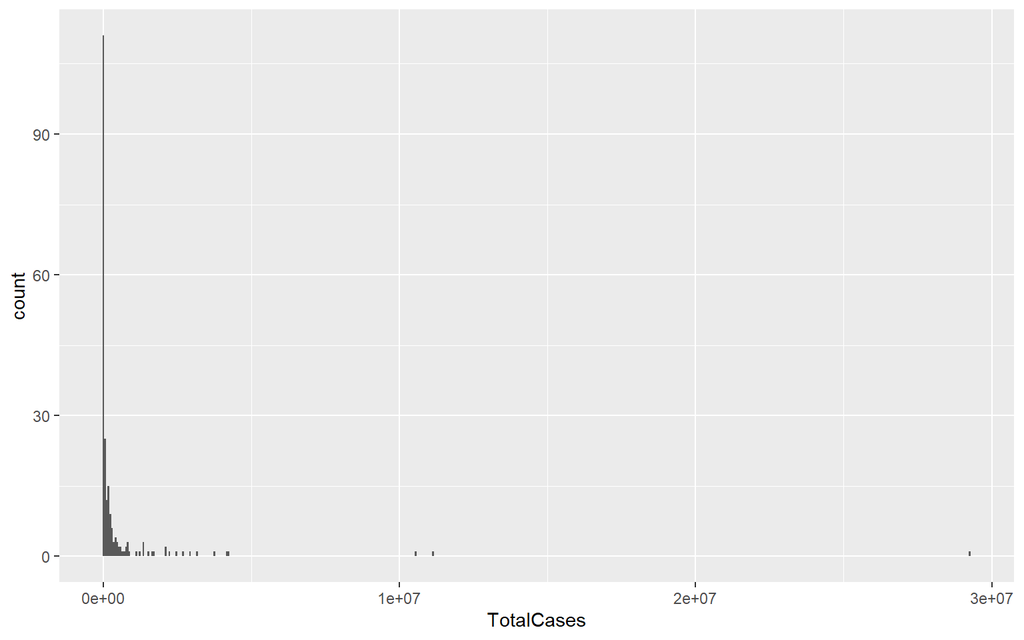

```r
ggplot(corona_data_character, aes(x = TotalCases))+
  geom_histogram(bins = 500)
```

- Created plot is highly skewed.
- If data is highly skewed, we try do log transformation.

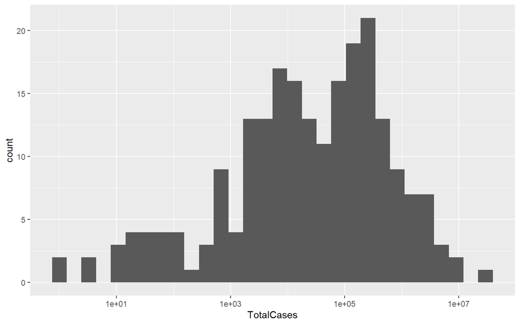

```r
ggplot(corona_data_character, aes(x = TotalCases))+
  scale_x_log10()+
  geom_histogram()
```

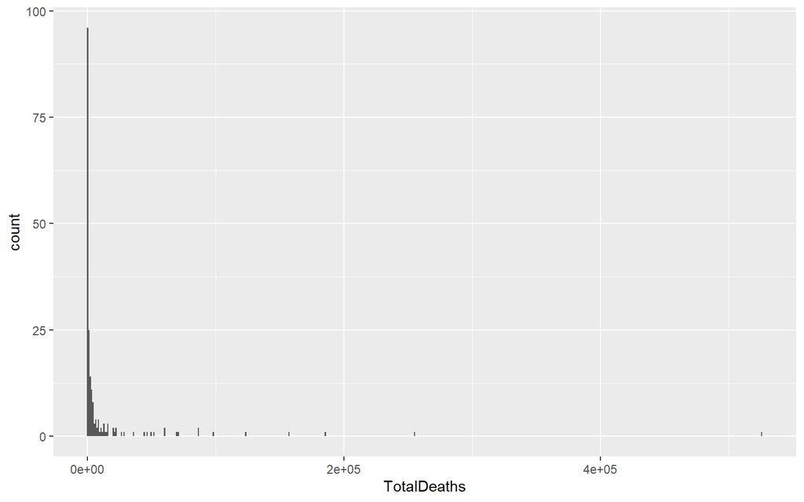

```r
ggplot(corona_data_character, aes(x = TotalDeaths))+
  geom_histogram(bins = 500)
```

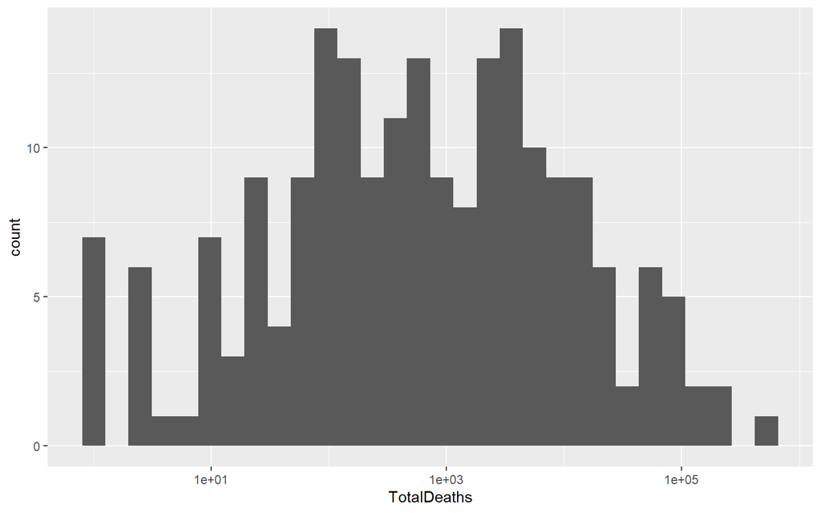

```r
ggplot(corona_data_character, aes(x = TotalDeaths))+
  scale_x_log10()+
  geom_histogram()
```

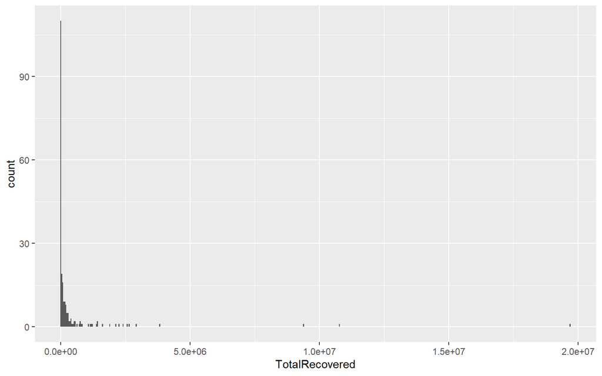

```r
ggplot(corona_data_character, aes(x = TotalRecovered))+
  geom_histogram(bins = 500)
```

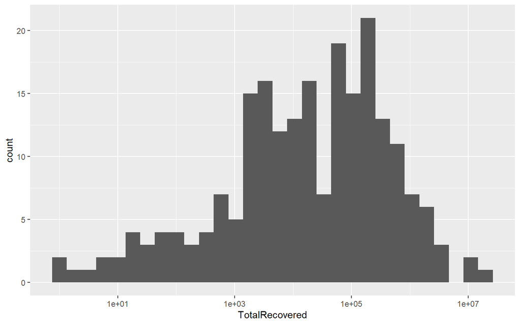

```r
ggplot(corona_data_character, aes(x = TotalRecovered))+
  scale_x_log10()+
  geom_histogram()
```

## Question 5. Create a plot to examine correlation between total cases and total population. Is there any correlation between it. Explain it.

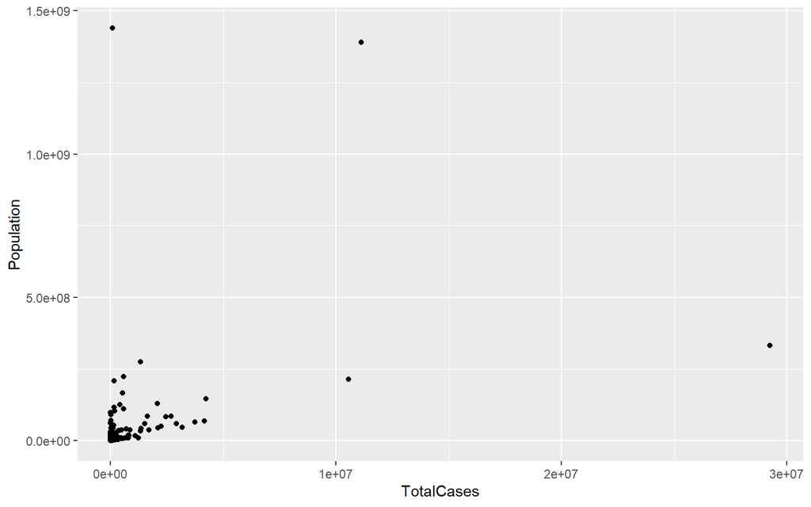

```r
ggplot(corona_data_character, aes(x = TotalCases, y = Population))+
  geom_point()
```

```r
skewness(corona_data_character$TotalCases)
```

```
## [1] 9.926452
```

```r
skewness(corona_data_character$Population, na.rm = TRUE)
```

```
## [1] 8.845929
```

```r
median(corona_data_character$TotalCases)
```

```
## [1] 28975
```

```r
IQR(corona_data_character$TotalCases)
```

```
## [1] 216202
```

```r
median(corona_data_character$Population, na.rm = TRUE)
```

```
## [1] 6595118
```

```r
IQR(corona_data_character$Population, na.rm = TRUE)
```

```
## [1] 23667577
```

- Data is mostly centered at one point. Hence any assumption of correlation is difficult.
- Skewness also suggested that data is highly skewed.
- Hence, to visualize data, transform it.

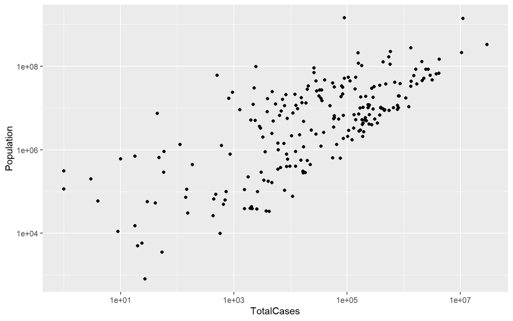

```r
ggplot(corona_data_character, aes(x = TotalCases, y = Population))+
  scale_x_log10()+
  scale_y_log10()+
  geom_point()
```

* After log transformation, it seems there is correlation between two variables.

## 6. Create a plot to examine correlation between Tot Cases/1M pop and total population. Is there any correlation between it.

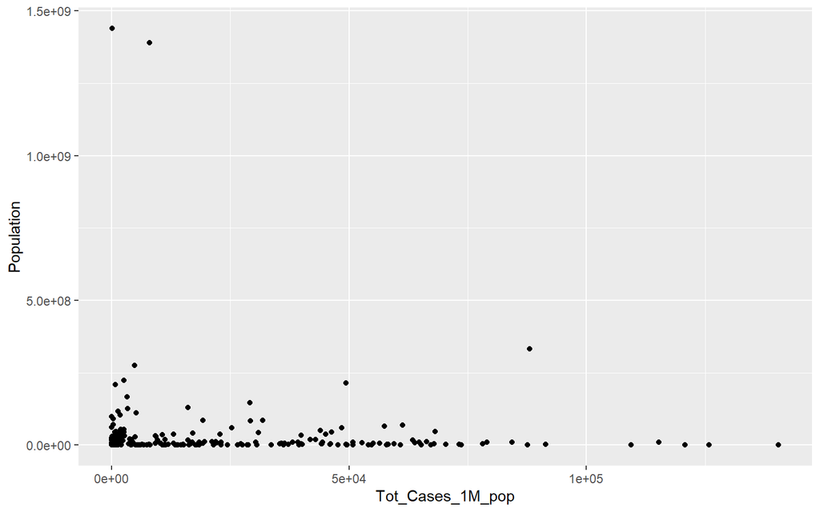

```r
ggplot(corona_data_character, aes(x = Tot_Cases_1M_pop, y = Population))+
  geom_point()
```

```r
skewness(corona_data_character$Tot_Cases_1M_pop, na.rm = TRUE)
```

```
## [1] 1.525221
```

```r
skewness(corona_data_character$Population, na.rm = TRUE)
```

```
## [1] 8.845929
```

```r
median(corona_data_character$Tot_Cases_1M_pop, na.rm = TRUE)
```

```
## [1] 11278
```

```r
IQR(corona_data_character$Tot_Cases_1M_pop, na.rm = TRUE)
```

```
## [1] 38337
```

```r
median(corona_data_character$Population, na.rm = TRUE)
```

```
## [1] 6595118
```

```r
IQR(corona_data_character$Population, na.rm = TRUE)
```

```
## [1] 23667577
```

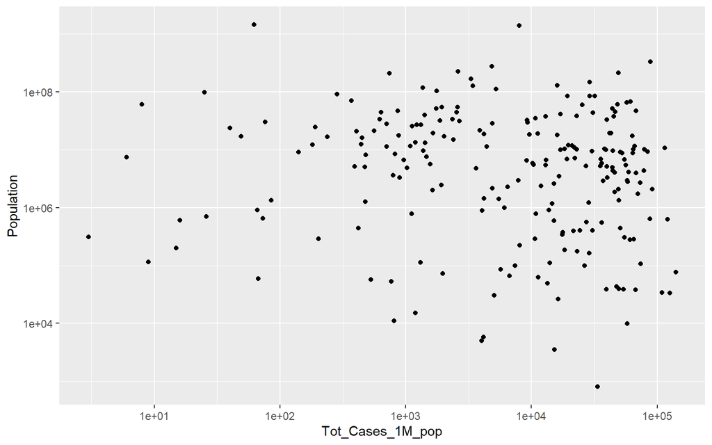

```r
ggplot(corona_data_character, aes(x = Tot_Cases_1M_pop, y = Population))+
  scale_x_log10()+
  scale_y_log10()+
  geom_point()
```

## Question 7. Which column do you feel is better for comparison purpose, total cases or TotCases/1M pop. Explain it.

- TotalCases/1M pop is better for comparison purpose. Original numbers in this type of cases can be superficial. Rates will be better to compare countries or continent.

## Question 8. Create a plot to examine correlation between total cases and total death. Explain the figure

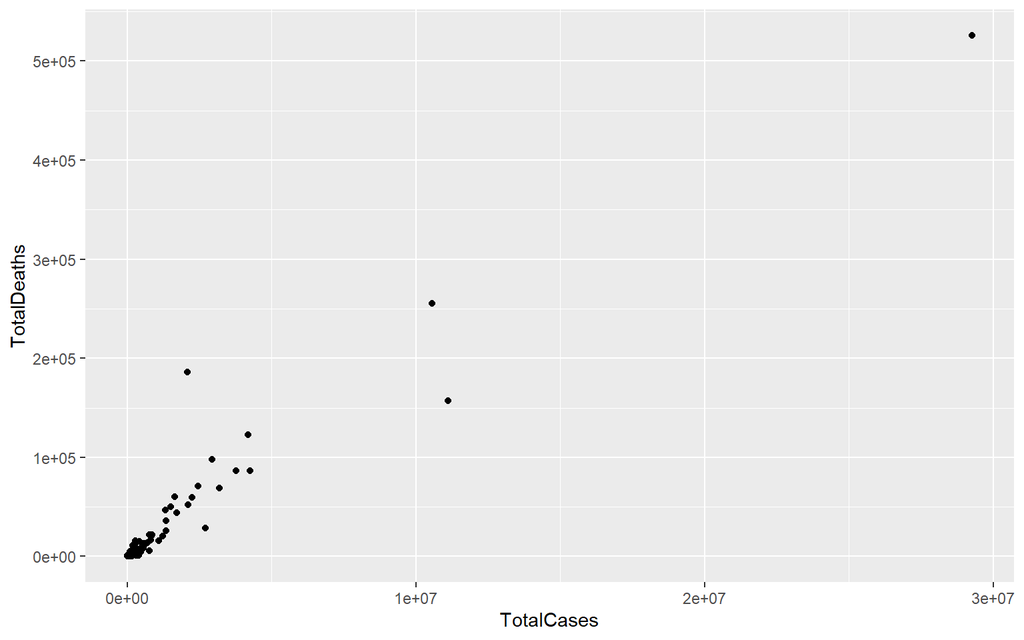

```r
ggplot(corona_data_character, aes(x = TotalCases, y = TotalDeaths))+
  geom_point()
```

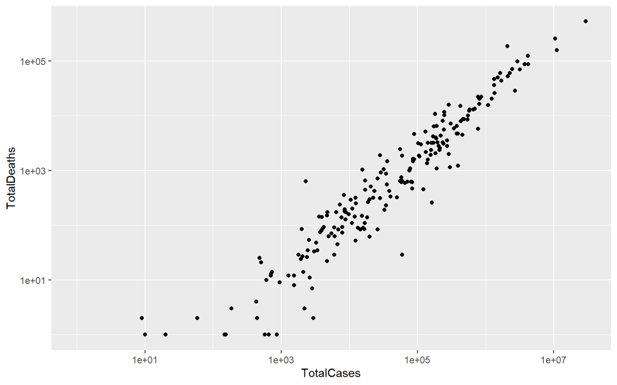

```r
ggplot(corona_data_character, aes(x = TotalCases, y = TotalDeaths))+
  scale_x_log10()+
  scale_y_log10()+
  geom_point()
```

## Question 9. Create a plot to examine correlation between total cases and Deaths/1M pop. Explain the figure. Again, which column is more suitable to compare the result, total death or Death/1Mpop?

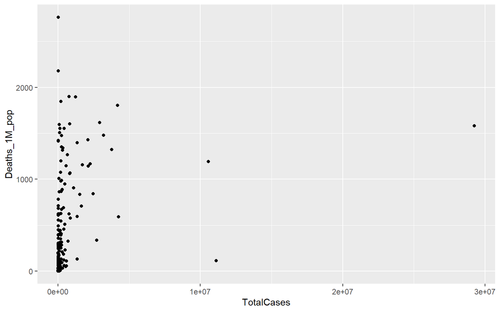

```r
ggplot(corona_data_character, aes(x = TotalCases, y = Deaths_1M_pop))+
  geom_point()
```

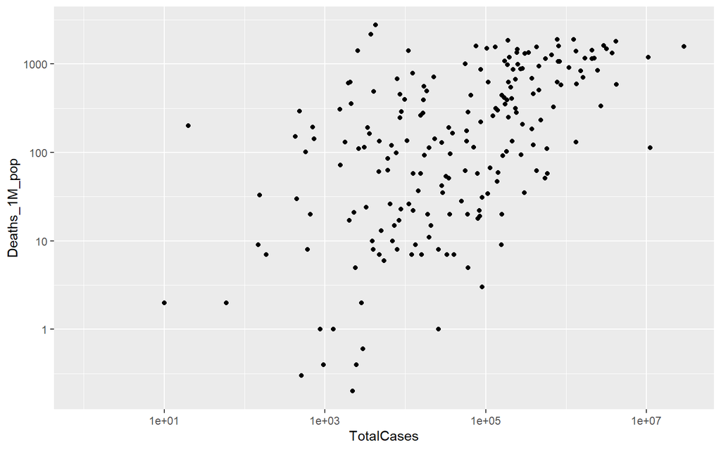

```r
ggplot(corona_data_character, aes(x = TotalCases, y = Deaths_1M_pop))+
  scale_x_log10()+
  scale_y_log10()+
  geom_point()
```

- There seems some correlation between two variables, as Total cases are increasng, death per million is also increasing

## Question 10. Compare TotCases/1M pop by continent, and explain your result.

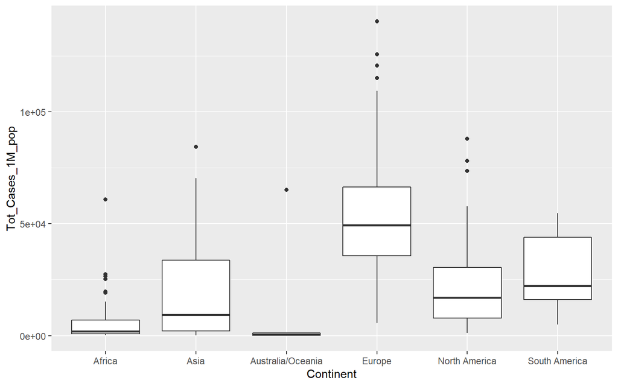

```r
corona_data_character %>%
  group_by(Continent) %>%
  na.omit(Continent) %>%
  ggplot(aes(x = Continent, y = Tot_Cases_1M_pop))+
  geom_boxplot()
```

```r
corona_data_character %>%
  group_by(Continent) %>%
  na.omit(Continent) %>%
  summarize(median_Totalcases_M = median(Tot_Cases_1M_pop, na.rm = TRUE))
```

```
## # A tibble: 6 x 2
##   Continent         median_Totalcases_M
##   <fct>                           <dbl>
## 1 Africa                           1813
## 2 Asia                             9299
## 3 Australia/Oceania                 475
## 4 Europe                          49338
## 5 North America                   17016
## 6 South America                   22179
```

## Question 11. Compare Deaths/1M pop by continent, and explain your result.

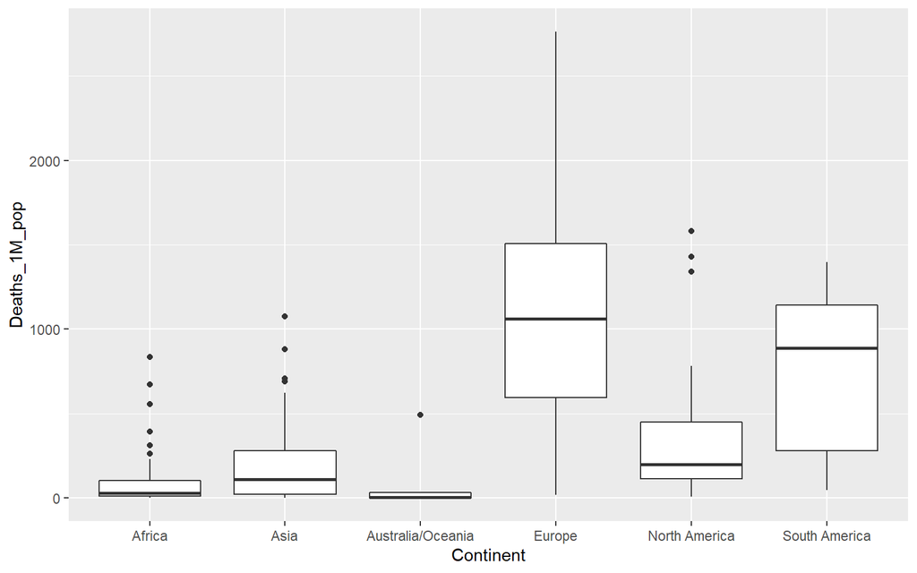

```r
corona_data_character %>%
  group_by(Continent) %>%
  na.omit(Continent) %>%
  ggplot(aes(x = Continent, y = Deaths_1M_pop))+
  geom_boxplot()
```

```r
corona_data_character %>%
  group_by(Continent) %>%
  na.omit(Continent) %>%
  summarize(median_Deaths_M = median(Deaths_1M_pop, na.rm = TRUE))
```

```
## # A tibble: 6 x 2
##   Continent         median_Deaths_M
##   <fct>                       <dbl>
## 1 Africa                         29
## 2 Asia                          111
## 3 Australia/Oceania               5
## 4 Europe                       1063
## 5 North America                 200
## 6 South America                 887
```

## Question 12. Which country is best among testing the COVID19 and which country is worst? There are two columns total test vs test/M. Choose appropriate column.

```r
summary(corona_data_character$Tests_1M_pop)
```

```
##    Min. 1st Qu.  Median    Mean 3rd Qu.    Max.    NA's
##     575   48097  191010  448030  520958 5540672      18
```

```r
corona_data_character %>%
  filter(Tests_1M_pop == 575)
```

```
##   Country TotalCases TotalDeaths TotalRecovered ActiveCases Tot_Cases_1M_pop
## 1   Yemen       2285         634           1435         216               76
##   Deaths_1M_pop TotalTests Tests_1M_pop Population Continent X1_Caseevery_X_ppl
## 1            21      17404          575   30257479      Asia              13242
##   X1_Deathevery_X_ppl X1_Testevery_X_ppl
## 1               47725               1739
```

```r
corona_data_character %>%
  filter(Tests_1M_pop == 5540672)
```

```
##     Country TotalCases TotalDeaths TotalRecovered ActiveCases Tot_Cases_1M_pop
## 1 Gibraltar       4239          93           4124          22           125846
##   Deaths_1M_pop TotalTests Tests_1M_pop Population Continent X1_Caseevery_X_ppl
## 1          2761     186632      5540672      33684    Europe                  8
##   X1_Deathevery_X_ppl X1_Testevery_X_ppl
## 1                 362                  0
```

## Question 13. Compare your COVID19 test results by continent? There are two columns total test vs test/M. Choose appropriate column.

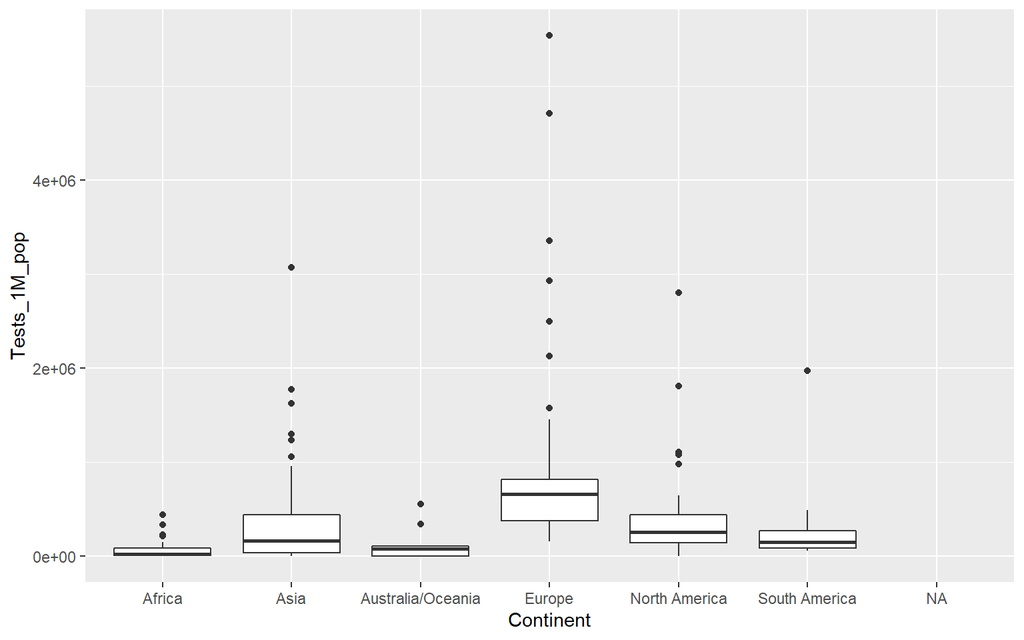

```r
corona_data_character %>%
  group_by(Continent) %>%
  ggplot(aes(x = Continent, y = Tests_1M_pop))+
  geom_boxplot()
```

```r
corona_data_character %>%
  group_by(Continent) %>%
  summarize(median_test_M = median(Tests_1M_pop, na.rm = TRUE))
```

```
## # A tibble: 7 x 2
##   Continent         median_test_M
##   <fct>                     <dbl>
## 1 Africa                   24983
## 2 Asia                    167737
## 3 Australia/Oceania        78754
## 4 Europe                  664422
## 5 North America           258084.
## 6 South America           148737
## 7 <NA>                        NA
```

- To compare it by continent, test/M is better to compare results.
- There is NA in continent section. Hence, we have to remove it.

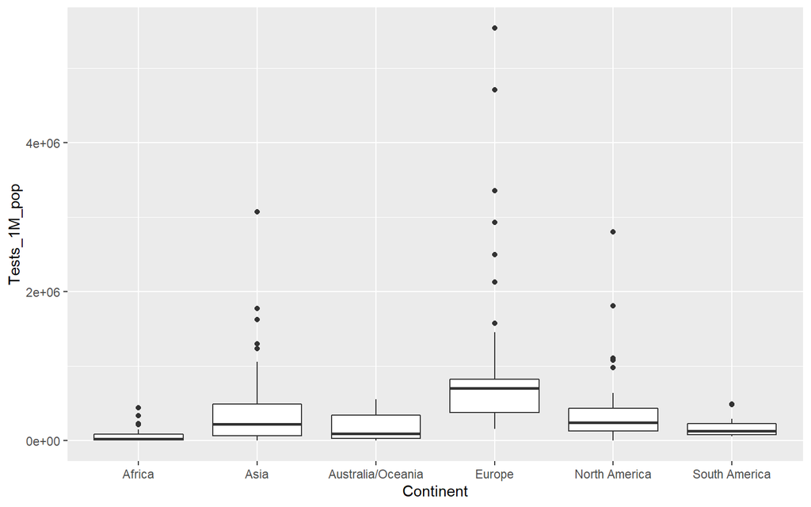

```r
corona_data_character %>%
  group_by(Continent) %>%
  na.omit(Continent) %>%
  ggplot(aes(x = Continent, y = Tests_1M_pop))+
  geom_boxplot()
```

```r
corona_data_character %>%
  group_by(Continent) %>%
  na.omit(Continent) %>%
  summarize(median_test_M = median(Tests_1M_pop, na.rm = TRUE))
```

```
## # A tibble: 6 x 2
##   Continent         median_test_M
##   <fct>                     <dbl>
## 1 Africa                    24983
## 2 Asia                     224908
## 3 Australia/Oceania         93463
## 4 Europe                   702068
## 5 North America            247119
## 6 South America            133920
```

- Results suggest that european continent has better testing
- African continent was worst in testing

## Question 14. Check if Tests/1M pop is skewed or normally distributed.

```r
skewness(corona_data_character$Tests_1M_pop, na.rm = TRUE)
```

```
## [1] 3.716781
```

- As skewness is > 3, it means data is highly skewed.

## Question 14. Check if Tests/1M pop is skewed or normally distributed.

```r
data_skew <- corona_data_character %>%
  group_by(Continent) %>%
  na.omit(Continent)

skewness(data_skew$Tests_1M_pop)
```

```
## [1] 3.69248
```